# SAGE Gait Study - Sub-Saharan Africa

### In-country Differences

#### South Africa Data

Table 3. Ethnicity in South Africa vs.Gait Speed

| **Ethnicity** | **Median Normal Gait Speed** | **Median Rapid Gait Speed** |
| --- | --- | --- |
| African/Black | 0.67 | 1.00 |
| White | 1.00 | 1.33 |
| Coloured | 0.71 | 1.08 |
| Indian/Asian | 0.74 | 1.00 |
| Other | 0.90 | 1.33 |

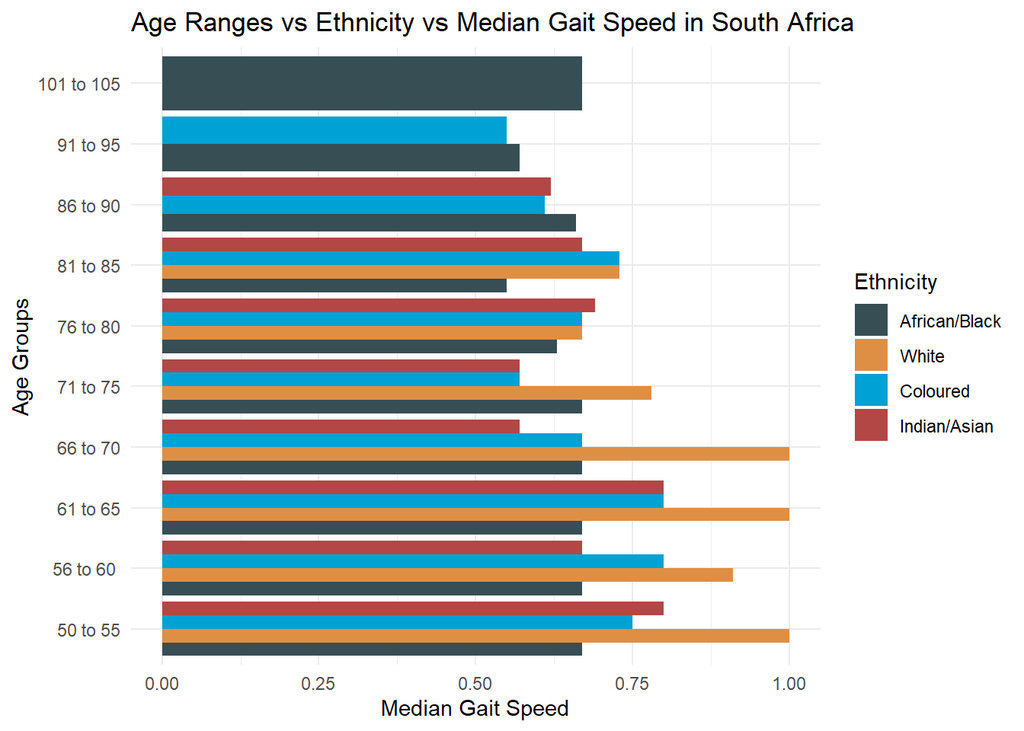

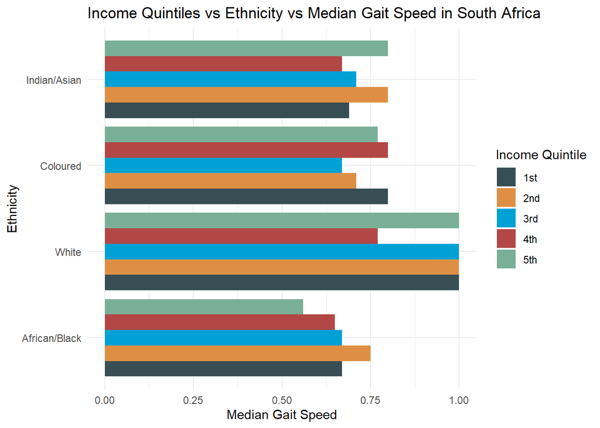

### In-Country and Gender Differences: Socio-Demographic Characteristics

More females in South Africa had more years of education as compared to males. The opposite was seen in Ghana. In both countries, more men were “currently married/cohabiting” as compared to women, and a higher proportion of females were widowed or “separated/divorced” as compared to males. In South Africa, more women had never married as compared to men. In Ghana, there was no gender difference.

**Table 4. In-country differences in demographics, gender-wise**

| **Characteristic** | **Ghana** **male**<sup>1</sup> | **Ghana** **female**<sup>1</sup> | **Ghana** **p-value**<sup>2</sup> | **South Africa** **male**<sup>1</sup> | **South Africa** **female**<sup>1</sup> | **South Africa** **p-value**<sup>2</sup> |
| --- | --- | --- | --- | --- | --- | --- |
| Age Groups (in years) |  |  | <0·001 |  |  | 0·030 |
| 50 to 59 | 890 (43%) | 713 (37%) |  | 662 (47%) | 829 (44%) |  |
| 60 to 69 | 612 (29%) | 512 (27%) |  | 461 (33%) | 609 (32%) |  |
| 70 to 79 | 399 (19%) | 498 (26%) |  | 204 (15%) | 342 (18%) |  |
| 80 and above | 180 (8·6%) | 188 (9·8%) |  | 77 (5·5%) | 118 (6·2%) |  |
| Age (in years) | 61 (55 – 70) | 64 (55 – 72) | <0·001 | 60 (55 – 67) | 61 (54 – 69) | 0·033 |
| Years of Education |  |  | <0·001 |  |  | 0·001 |
| 0 | 955 (46%) | 1 284 (67%) |  | 584 (42%) | 701 (37%) |  |
| 1 to 12 | 878 (42%) | 550 (29%) |  | 714 (51%) | 1 085 (57%) |  |
| 12 and above | 248 (12%) | 77 (4·0%) |  | 106 (7·5%) | 112 (5·9%) |  |
| Residence |  |  | <0·001 |  |  | 0·75 |
| rural | 1 312 (63%) | 1 068 (56%) |  | 472 (34%) | 628 (33%) |  |
| urban | 769 (37%) | 843 (44%) |  | 932 (66%) | 1 270 (67%) |  |
| Marital Status |  |  | <0·001 |  |  | <0·001 |
| cohabiting/currently married | 1 743 (84%) | 529 (28%) |  | 1 054 (75%) | 678 (36%) |  |
| widowed | 136 (6·5%) | 955 (50%) |  | 141 (10%) | 736 (39%) |  |
| separated/divorced | 171 (8·2%) | 393 (21%) |  | 71 (5·1%) | 122 (6·4%) |  |
| never married | 22 (1·1%) | 22 (1·2%) |  | 120 (8·5%) | 323 (17%) |  |
| don't know | 9 (0·4%) | 12 (0·6%) |  | 18 (1·3%) | 39 (2·1%) |  |
| Income (in quintiles) |  |  | <0·001 |  |  | <0·001 |
| 1st | 395 (19%) | 402 (21%) |  | 241 (17%) | 359 (19%) |  |
| 2nd | 376 (18%) | 411 (22%) |  | 287 (20%) | 372 (20%) |  |
| 3rd | 414 (20%) | 381 (20%) |  | 234 (17%) | 428 (23%) |  |
| 4th | 429 (21%) | 387 (20%) |  | 290 (21%) | 400 (21%) |  |
| 5th | 467 (22%) | 330 (17%) |  | 352 (25%) | 339 (18%) |  |
| Normal Gait Speed | 0·77 (0·59 – 0·93) | 0·66 (0·56 – 0·83) | <0·001 | 0·80 (0·57 – 1·00) | 0·67 (0·55 – 0·93) | <0·001 |
| Rapid Gait Speed | 1·21 (0·98 – 1·38) | 1·00 (0·89 – 1·25) | <0·001 | 1·14 (0·80 – 1·33) | 1·00 (0·80 – 1·33) | <0·001 |

<sup>1</sup> n (%); Median (IQR)  
<sup>2</sup> Pearson's Chi-squared test; Wilcoxon rank sum test

### In-Country and Gender Differences: Co-Morbidities

Generally, more people did not have a history of alcohol use in both countries. For those who did though, slightly more women had a positive history as compared to men.

For tobacco use, almost four times more women in South Africa had a positive history compared to women in Ghana. there was not much difference between men across the two countries.

In total, women had more positive histories of comorbidities as compared to men.

**Table 5. In-country differences in co-morbidities, gender-wise**

| **Characteristic** | **Ghana** **male**<sup>1</sup> | **Ghana** **female**<sup>1</sup> | **Ghana** **p-value**<sup>2</sup> | **South Africa** **male**<sup>1</sup> | **South Africa** **female**<sup>1</sup> | **South Africa** **p-value**<sup>2</sup> |
| --- | --- | --- | --- | --- | --- | --- |
| History of Alcohol use |  |  | 0·002 |  |  | 0·005 |
| no | 1 606 (78%) | 1 400 (73%) |  | 1 027 (70%) | 1 315 (65%) |  |
| yes | 461 (22%) | 507 (27%) |  | 447 (30%) | 703 (35%) |  |
| History of Tobacco use |  |  | <0·001 |  |  | <0·001 |
| no | 1 189 (58%) | 1 755 (92%) |  | 836 (57%) | 1 432 (71%) |  |
| yes | 878 (42%) | 152 (8·0%) |  | 638 (43%) | 586 (29%) |  |
| History of Depression |  |  | <0·001 |  |  | 0·24 |
| no | 2 049 (99%) | 1 863 (98%) |  | 1 434 (97%) | 1 949 (97%) |  |
| yes | 18 (0·9%) | 44 (2·3%) |  | 40 (2·7%) | 69 (3·4%) |  |
| History of Diabetes Mellitus |  |  | 0·045 |  |  | 0·007 |
| no | 2 002 (97%) | 1 824 (96%) |  | 1 348 (91%) | 1 789 (89%) |  |
| yes | 65 (3·1%) | 83 (4·4%) |  | 126 (8·5%) | 229 (11%) |  |
| History of Asthma and Chronic Lung Disease |  |  | 0·072 |  |  | 0·29 |
| no | 1 881 (91%) | 1 703 (89%) |  | 1 400 (95%) | 1 900 (94%) |  |
| yes | 186 (9·0%) | 204 (11%) |  | 74 (5·0%) | 118 (5·8%) |  |
| History of Arthritis and Musculoskeletal Pains |  |  | 0·47 |  |  | 0·037 |
| no | 1 126 (54%) | 1 017 (53%) |  | 729 (49%) | 926 (46%) |  |
| yes | 941 (46%) | 890 (47%) |  | 745 (51%) | 1 092 (54%) |  |
| History of Stroke |  |  | 0·78 |  |  | 0·33 |
| no | 2 003 (97%) | 1 845 (97%) |  | 1 408 (96%) | 1 913 (95%) |  |
| yes | 64 (3·1%) | 62 (3·3%) |  | 66 (4·5%) | 105 (5·2%) |  |
| History of Angina |  |  | 0·002 |  |  | 0·017 |
| no | 1 606 (78%) | 1 400 (73%) |  | 1 213 (82%) | 1 595 (79%) |  |
| yes | 461 (22%) | 507 (27%) |  | 261 (18%) | 423 (21%) |  |
| History of Hypertension |  |  | 0·019 |  |  | 0·007 |
| no | 1 824 (88%) | 1 635 (86%) |  | 1 016 (69%) | 1 303 (65%) |  |
| yes | 243 (12%) | 272 (14%) |  | 458 (31%) | 715 (35%) |  |
| History of Cataracts |  |  | 0·002 |  |  | 0·005 |
| no | 1 606 (78%) | 1 400 (73%) |  | 1 027 (70%) | 1 315 (65%) |  |
| yes | 461 (22%) | 507 (27%) |  | 447 (30%) | 703 (35%) |  |

<sup>1</sup> n (%)  
<sup>2</sup> Pearson's Chi-squared test

### Comparison of Gait Speed Across Demographic Variables

The table below shows the multiple regression results with the gait speed as the outcome variable and the various demographics variables as the independent variables.

**Table 6. Multiple Regression: Gait Speed vs Demographic Variables**

| **Characteristic** | **Ghana** **N** | **Ghana** **Beta** | **Ghana** **95% CI**<sup>1</sup> | **Ghana** **p-value** | **South Africa** **N** | **South Africa** **Beta** | **South Africa** **95% CI**<sup>1</sup> | **South Africa** **p-value** |
| --- | --- | --- | --- | --- | --- | --- | --- | --- |
| Age Groups (in years) | 4 726 |  |  |  | 3 580 |  |  |  |
| 18 to 49 |  | — | — |  |  | — | — |  |
| 50 to 59 |  | -0·03 | -0·04 to -0·01 | <0·001 |  | -0·04 | -0·06 to -0·02 | <0·001 |
| 60 to 69 |  | -0·05 | -0·07 to -0·04 | <0·001 |  | -0·06 | -0·08 to -0·04 | <0·001 |
| 70 to 79 |  | -0·09 | -0·11 to -0·08 | <0·001 |  | -0·09 | -0·11 to -0·07 | <0·001 |
| 80 and above |  | -0·12 | -0·14 to -0·10 | <0·001 |  | -0·11 | -0·14 to -0·08 | <0·001 |
| Years of Education | 4 726 |  |  |  | 3 580 |  |  |  |
| 0 |  | — | — |  |  | — | — |  |
| 1 to 12 |  | 0·02 | 0·01 to 0·03 | <0·001 |  | 0·01 | 0·00 to 0·02 | 0·18 |
| 12 and above |  | 0·03 | 0·02 to 0·05 | <0·001 |  | 0·01 | -0·02 to 0·03 | 0·45 |
| Marital Status | 4 726 |  |  |  | 3 580 |  |  |  |
| cohabiting/currently married |  | — | — |  |  | — | — |  |
| never married |  | 0·03 | 0·00 to 0·05 | 0·048 |  | -0·03 | -0·04 to -0·01 | 0·002 |
| separated/divorced |  | -0·05 | -0·06 to -0·04 | <0·001 |  | -0·03 | -0·05 to 0·00 | 0·044 |
| widowed |  | -0·07 | -0·08 to -0·06 | <0·001 |  | -0·06 | -0·07 to -0·04 | <0·001 |
| Residence | 4 726 |  |  |  | 3 580 |  |  |  |
| rural |  | — | — |  |  | — | — |  |
| urban |  | -0·02 | -0·03 to -0·01 | <0·001 |  | -0·02 | -0·03 to -0·01 | 0·001 |
| Sex | 4 726 |  |  |  | 3 580 |  |  |  |
| female |  | — | — |  |  | — | — |  |
| male |  | 0·05 | 0·04 to 0·06 | <0·001 |  | 0·04 | 0·03 to 0·05 | <0·001 |
| Income (in quintiles) | 4 726 |  |  |  | 3 580 |  |  |  |
| 1st |  | — | — |  |  | — | — |  |
| 2nd |  | -0·02 | -0·03 to -0·01 | 0·003 |  | 0·01 | -0·01 to 0·03 | 0·20 |
| 3rd |  | -0·03 | -0·04 to -0·01 | <0·001 |  | -0·01 | -0·03 to 0·01 | 0·45 |
| 4th |  | -0·01 | -0·02 to 0·00 | 0·18 |  | -0·01 | -0·03 to 0·01 | 0·17 |
| 5th |  | -0·01 | -0·02 to 0·00 | 0·10 |  | 0·02 | 0·00 to 0·04 | 0·061 |

<sup>1</sup> CI = Confidence Interval

### Comparison of Gait Speed Across Health-Related variables

History of Depression reduced gait speed significantly for “yes” relative to “no” in Ghana but not in South Africa.

**Table 7. Multiple Regression: Gait Speed vs Health-Related Variables**

| **Characteristic** | **Ghana** **N** | **Ghana** **Beta** | **Ghana** **95% CI**<sup>1</sup> | **Ghana** **p-value** | **South Africa** **N** | **South Africa** **Beta** | **South Africa** **95% CI**<sup>1</sup> | **South Africa** **p-value** |
| --- | --- | --- | --- | --- | --- | --- | --- | --- |
| History of Alcohol use | 4 405 |  |  |  | 3 440 |  |  |  |
| no |  | — | — |  |  | — | — |  |
| yes |  | -0·01 | -0·02 to 0·00 | 0·025 |  | 0·01 | 0·00 to 0·03 | 0·033 |
| History of Tobacco use | 4 405 |  |  |  | 3 440 |  |  |  |
| no |  | — | — |  |  | — | — |  |
| yes |  | 0·02 | 0·01 to 0·03 | <0·001 |  | 0·02 | 0·00 to 0·03 | 0·019 |
| History of Depression | 4 405 |  |  |  | 3 440 |  |  |  |
| no |  | — | — |  |  | — | — |  |
| yes |  | -0·07 | -0·11 to -0·04 | <0·001 |  | 0·01 | -0·03 to 0·04 | 0·69 |
| History of Diabetes Mellitus | 4 405 |  |  |  | 3 440 |  |  |  |
| no |  | — | — |  |  | — | — |  |
| yes |  | -0·03 | -0·06 to -0·01 | 0·009 |  | -0·06 | -0·08 to -0·04 | <0·001 |
| History of Asthma and Chronic Lung Disease | 4 405 |  |  |  | 3 440 |  |  |  |
| no |  | — | — |  |  | — | — |  |
| yes |  | -0·01 | -0·02 to 0·00 | 0·11 |  | 0·00 | -0·02 to 0·03 | 0·90 |
| History of Arthritis and Musculoskeletal Pains | 4 405 |  |  |  | 3 440 |  |  |  |
| no |  | — | — |  |  | — | — |  |
| yes |  | 0·02 | 0·01 to 0·03 | <0·001 |  | 0·01 | -0·01 to 0·02 | 0·33 |
| History of Stroke | 4 405 |  |  |  | 3 440 |  |  |  |
| no |  | — | — |  |  | — | — |  |
| yes |  | 0·02 | 0·00 to 0·05 | 0·040 |  | 0·00 | -0·03 to 0·03 | 0·99 |
| History of Angina | 4 405 |  |  |  | 3 440 |  |  |  |
| no |  | — | — |  |  | — | — |  |
| yes |  | -0·01 | -0·02 to 0·00 | 0·025 |  | -0·03 | -0·05 to -0·01 | <0·001 |
| History of Cataracts | 4 405 |  |  |  | 3 440 |  |  |  |
| no |  | — | — |  |  | — | — |  |
| yes |  | -0·01 | -0·02 to 0·00 | 0·025 |  | 0·01 | 0·00 to 0·03 | 0·033 |

<sup>1</sup> CI = Confidence Interval

#### Association of health indices with gait speed

Using the 12-item World Health Organization’s Disability Assessment Schedule, version 2 (WHODAS-II), respondent’s functional ability was measured. The 12-item questionnaire measured the activities of daily living(ADLs) and instrumental activities of daily living (IADLs).

The WHODAS-related variables are a series of questions that start with the following preamble: “Overall in the last 30 days, how much difficulty…”, followed by various parameters/tasks. The respondents’ answers were re-coded with **0 equivalent to “none”, 1 equivalent to “mild”, 2 to “moderate”, 3 to “severe” and 4 to “extreme”.** Across the 12 variables, a respondent could score a **minimum of 0 and a maximum of 48.** The table below compares the 12-item WHODAS variables in general, and specifically the three questions which deal with the ADLs, as well as height, and BMI and gait speed.

**Table 8. Median Gait Speed According to BMI,WHODAS and ADLs**

| **Characteristic** | **male** **N = 3 351**<sup>1</sup> | **female** **N = 3 599**<sup>1</sup> |
| --- | --- | --- |
| height (in metres) |  |  |
| above average | 0·80 (0·62, 0·93) | 0·77 (0·57, 0·93) |
| average | 0·77 (0·57, 0·93) | 0·67 (0·56, 0·89) |
| below average | 0·67 (0·56, 0·93) | 0·66 (0·56, 0·82) |
| BMI |  |  |
| Normal Weight | 0·80 (0·59, 0·93) | 0·68 (0·56, 0·89) |
| Underweight | 0·75 (0·60, 0·93) | 0·66 (0·56, 0·85) |
| Overweight | 0·80 (0·60, 0·93) | 0·70 (0·56, 0·93) |
| Obese | 0·70 (0·56, 0·93) | 0·63 (0·55, 0·80) |
| WHODAS score |  |  |
| none/mild | 0·91 (0·71, 1·00) | 0·82 (0·67, 1·00) |
| moderate | 0·77 (0·58, 0·93) | 0·68 (0·56, 0·89) |
| severe | 0·62 (0·56, 0·83) | 0·56 (0·56, 0·74) |
| Difficulty in getting dressed |  |  |
| none | 0·80 (0·59, 0·93) | 0·68 (0·56, 0·89) |
| moderate | 0·67 (0·56, 0·93) | 0·56 (0·56, 0·77) |
| Difficulty with eating |  |  |
| none | 0·80 (0·59, 0·93) | 0·67 (0·56, 0·89) |
| moderate | 0·67 (0·56, 0·93) | 0·57 (0·56, 0·80) |
| Difficulty with getting to and using the toilet |  |  |
| none | 0·80 (0·60, 0·93) | 0·69 (0·56, 0·91) |
| moderate | 0·67 (0·56, 0·93) | 0·57 (0·56, 0·80) |

<sup>1</sup> Gait Speed: Median (IQR); Median

### Trend of Gait Speed With Age

It can be seen clearly in the graphs below that there is a decline in gait speed with increasing age:

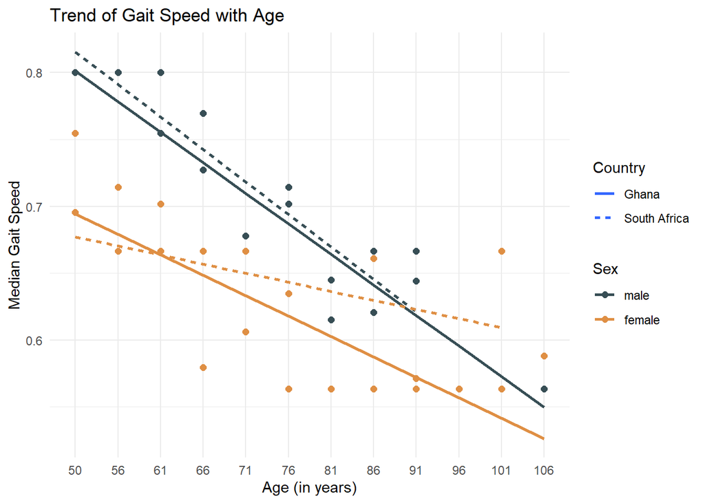

### Zooming In To 75+

The black line represents the linear regression model with the shaded area representing the 95% confidence interval.

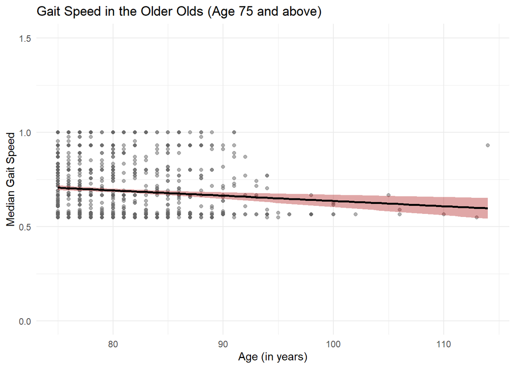

### Respondents’ subjective assessment of pain, health and energy levels

### Association of Health Rating with gait speed

The graph below shows respondents’ subjective assessment of health level and it’s association with gait speed. The line in the box represents the median, and the entire box represents the interquartile range. The density of the surrounding dotted area represents the number of respondents’ who chose that answer as their health rating.

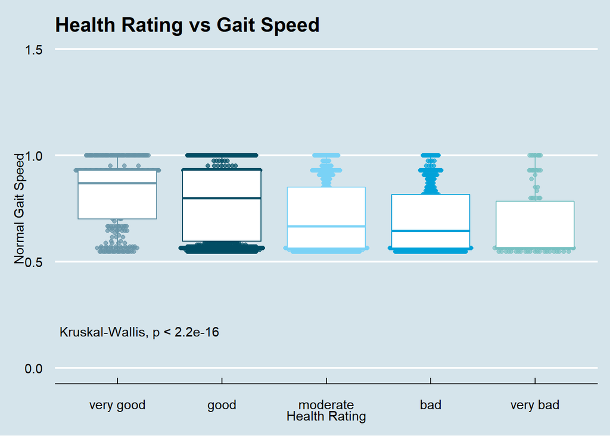

**Table 9. Median Gait Speed According to Age and Exhaustion Severity**

| **Characteristic** | **none** **N = 3 576**<sup>1</sup> | **mild** **N = 1 805**<sup>1</sup> | **moderate** **N = 1 490**<sup>1</sup> | **severe** **N = 468**<sup>1</sup> | **extreme** **N = 16**<sup>1</sup> |
| --- | --- | --- | --- | --- | --- |
| Ages |  |  |  |  |  |
| 50 to 55 | 0·80 (0·65, 0·93) | 0·70 (0·56, 0·93) | 0·71 (0·57, 0·93) | 0·66 (0·55, 0·82) | 0·57 (0·56, 0·64) |
| 56 to 60 | 0·80 (0·62, 0·93) | 0·71 (0·57, 0·91) | 0·67 (0·56, 0·89) | 0·66 (0·56, 0·80) | 0·67 (0·62, 0·75) |
| 61 to 65 | 0·80 (0·60, 0·93) | 0·67 (0·56, 0·89) | 0·67 (0·56, 0·91) | 0·67 (0·56, 0·80) | 0·93 (0·93, 0·93) |
| 66 to 70 | 0·71 (0·56, 0·93) | 0·63 (0·56, 0·82) | 0·65 (0·56, 0·87) | 0·65 (0·56, 0·79) | 0·55 (0·55, 0·55) |
| 71 to 75 | 0·69 (0·56, 0·88) | 0·64 (0·56, 0·82) | 0·57 (0·56, 0·80) | 0·56 (0·56, 0·82) | 0·93 (0·93, 0·93) |
| 76 to 80 | 0·67 (0·56, 0·85) | 0·65 (0·56, 0·80) | 0·58 (0·56, 0·83) | 0·56 (0·56, 0·68) | 0·58 (0·56, 0·60) |
| 81 to 85 | 0·65 (0·56, 0·83) | 0·59 (0·56, 0·78) | 0·56 (0·56, 0·67) | 0·57 (0·56, 0·79) | 0·57 (0·57, 0·57) |
| 86 to 90 | 0·69 (0·57, 0·93) | 0·57 (0·56, 0·80) | 0·56 (0·56, 0·60) | 0·56 (0·56, 0·69) | NA (NA, NA) |
| 91 to 95 | 0·71 (0·58, 0·88) | 0·67 (0·56, 0·73) | 0·70 (0·58, 0·81) | 0·56 (0·56, 0·62) | 0·55 (0·55, 0·55) |
| 96 to 100 | 0·59 (0·58, 0·60) | 0·56 (0·56, 0·59) | 0·56 (0·56, 0·56) | 0·56 (0·56, 0·58) | NA (NA, NA) |

<sup>1</sup> Gait Speed: Median (IQR); Median

**Table 10. Median Gait Speed According to Age and Pain Severity**

| **Characteristic** | **none** **N = 562**<sup>1</sup> | **mild** **N = 2 300**<sup>1</sup> | **moderate** **N = 1 797**<sup>1</sup> | **severe** **N = 614**<sup>1</sup> | **extreme** **N = 16**<sup>1</sup> |
| --- | --- | --- | --- | --- | --- |
| Ages |  |  |  |  |  |
| 50 to 55 | 0·80 (0·61, 0·93) | 0·75 (0·57, 0·93) | 0·68 (0·56, 0·91) | 0·66 (0·56, 0·80) | 0·79 (0·73, 0·86) |
| 56 to 60 | 0·80 (0·67, 0·93) | 0·70 (0·57, 0·91) | 0·67 (0·56, 0·87) | 0·67 (0·56, 0·91) | 0·62 (0·55, 0·75) |
| 61 to 65 | 0·77 (0·57, 0·92) | 0·67 (0·56, 0·91) | 0·68 (0·56, 0·91) | 0·65 (0·56, 0·83) | 0·56 (0·56, 0·56) |
| 66 to 70 | 0·68 (0·57, 0·85) | 0·67 (0·56, 0·88) | 0·64 (0·56, 0·82) | 0·57 (0·56, 0·82) | 0·82 (0·76, 0·87) |
| 71 to 75 | 0·67 (0·56, 0·82) | 0·62 (0·56, 0·80) | 0·66 (0·56, 0·84) | 0·63 (0·56, 0·80) | NA (NA, NA) |
| 76 to 80 | 0·67 (0·56, 0·87) | 0·64 (0·56, 0·82) | 0·62 (0·56, 0·80) | 0·56 (0·56, 0·70) | NA (NA, NA) |
| 81 to 85 | 0·71 (0·56, 0·93) | 0·57 (0·56, 0·78) | 0·58 (0·56, 0·79) | 0·56 (0·56, 0·60) | 0·56 (0·56, 0·56) |
| 86 to 90 | 0·77 (0·70, 0·87) | 0·57 (0·56, 0·66) | 0·57 (0·56, 0·80) | 0·64 (0·56, 0·70) | 0·56 (0·56, 0·66) |
| 91 to 95 | 0·82 (0·71, 0·90) | 0·71 (0·69, 0·74) | 0·64 (0·56, 0·75) | 0·56 (0·56, 0·69) | NA (NA, NA) |
| 96 to 100 | NA (NA, NA) | 0·56 (0·56, 0·56) | 0·59 (0·56, 0·63) | 0·56 (0·56, 0·56) | NA (NA, NA) |

<sup>1</sup> Gait Speed: Median (IQR); Median